# Phillipines Trust Index

Summary

This page presents additional analysis of survey data collected by the Philippine Red Cross (PRCS) during February and March 2023, covering questions around trust as part of the Trust Index project.

# Sampling

## Coverage

[interactive chart not shown]

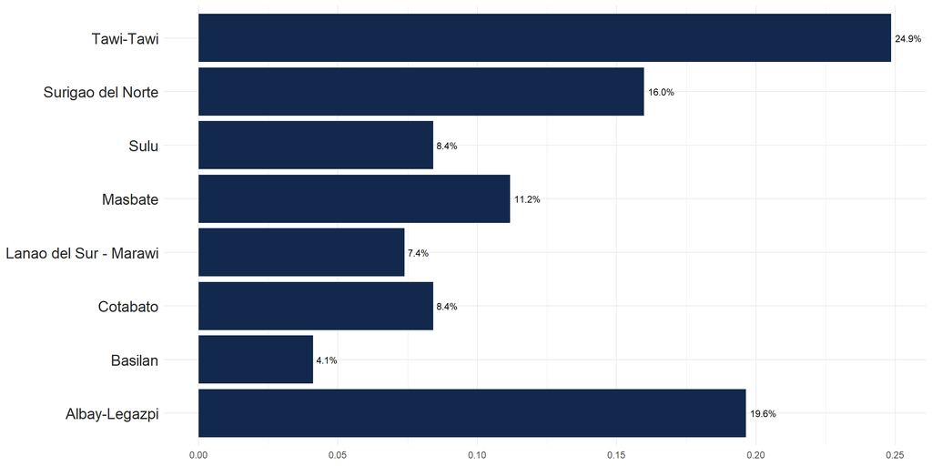

## Gender and age group

Compared to the overall Philippine population in the sample, women especially older women are over-represented, while younger people are under-represented.

| Demographic | Total | Female | Male | Other |
| --- | --- | --- | --- | --- |
| Respondents | 2897 | 1980 | 904 | 13 |

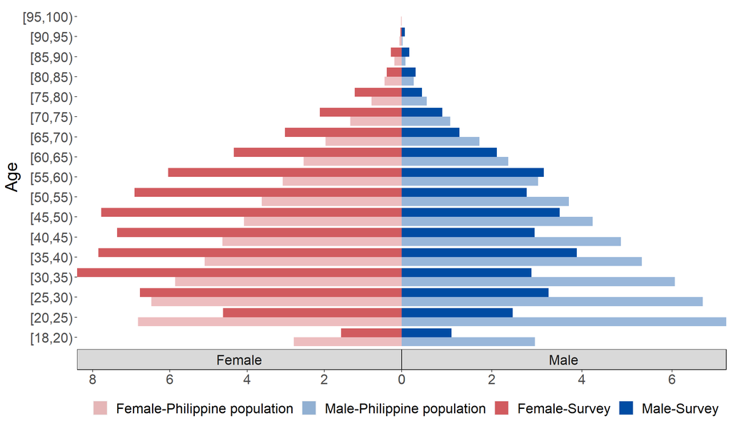

## Education

When it comes to highest level of education, the survey respondents with no formal education as well as people with only primary school education are over-represented in the sample, compared to World Bank data of the overall population. People with secondary education are under-represented in the sample.

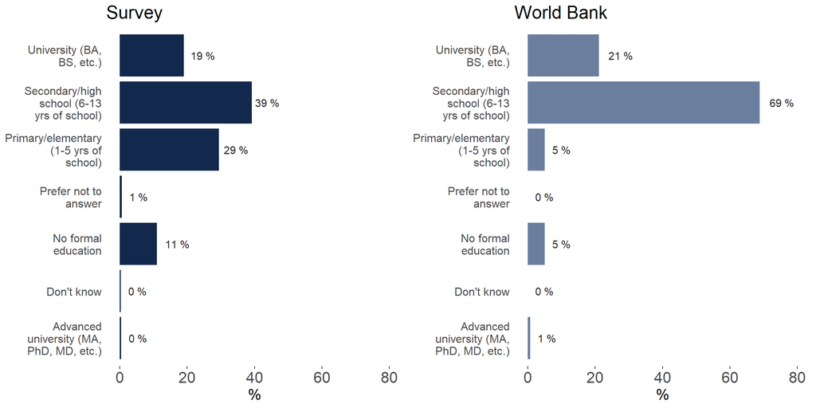

## Relationship with Red Cross

To better understand community trust, we identified previous relationships with the Philippines Red Cross. We distinguished between people who are Red Cross volunteers, people who had previously received assistance from the Red Cross (referred to here as ‘beneficiaries’), people who had previous support or donate to the Red Cross (referred to here as ‘donors’) and those who had never received assistance (referred to as ‘others’). This study did not focus on Red Cross volunteers.

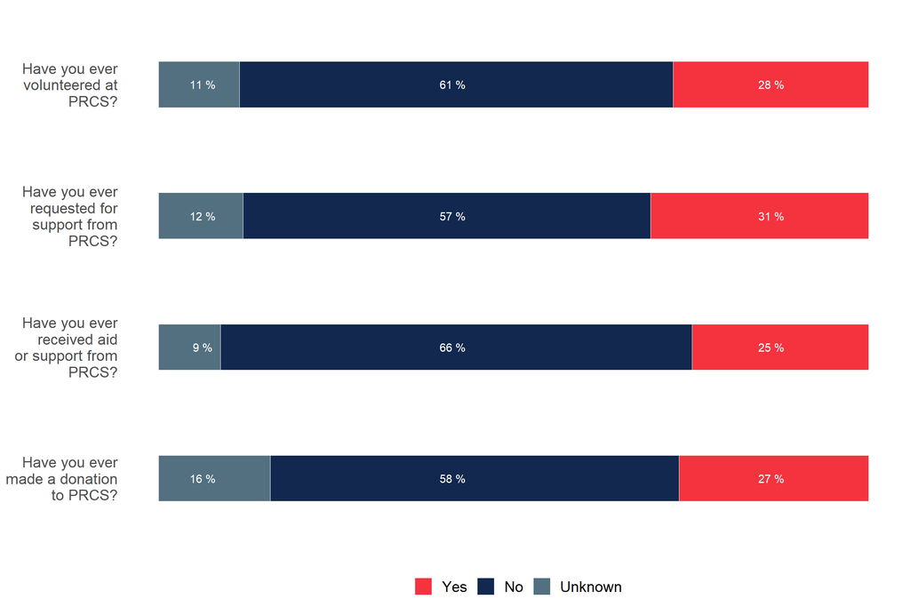

# Results

When looking at the overall results for competency and values, we see no major differences between age groups, gender, and rural/urban settings. The largest differences we see among district, occupation as well as education.

## Score distribution

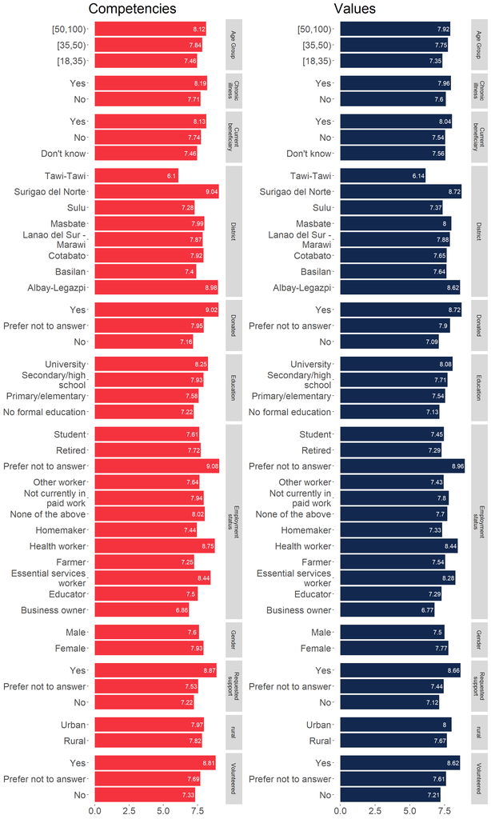

## Weighting

The survey data has been weighted based estimated population size of the district and the response rate of each sampled neighborhood. In addition, adjustments were made to re-balance the gender ratio in accordance with Philippine census 2021 estimates. For comparison we included also un-weighted results in the graph, as well as the sub-set of the data for volunteers, people who indicate to have received support from the PRCS as well as the group that neither volunteered nor received assistance.

Overall, we see no major differences between these groups, the weighted data means are slightly more positive than un-weighted data.

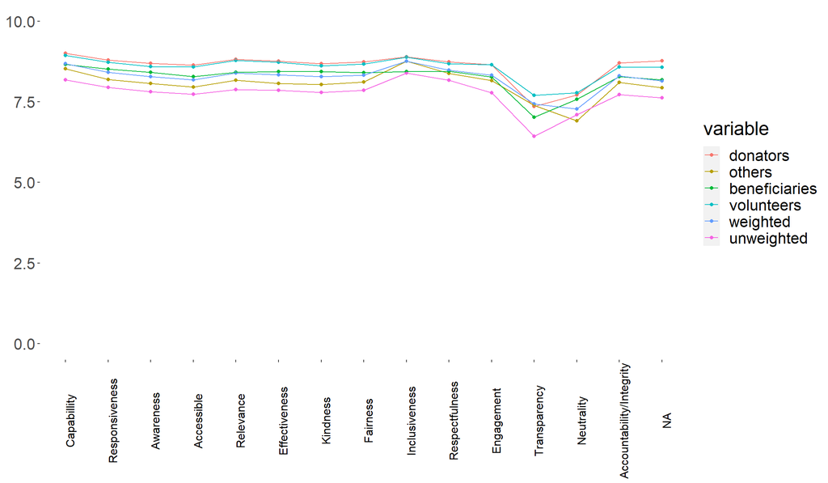

## Weighted score

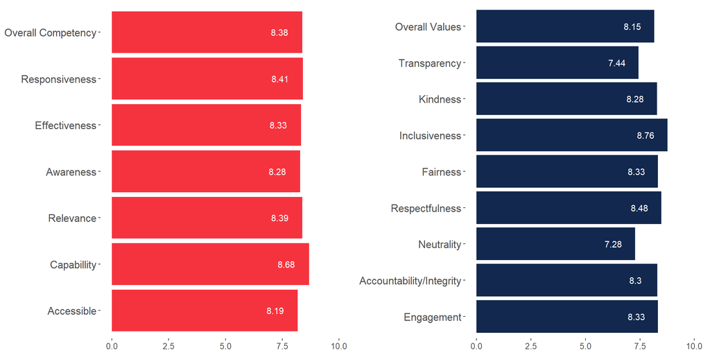

## Results per participants

When looking at the sub-groups of people who volunteered and beneficiaries as well as others, we see that people who volunteer provide the most positive rating from the three groups. In terms of beneficiaries they rate the PRCS higher than the non-volunteer/beneficiaries in terms all the question on competencies, and most of the questions on values (except transparency and inclusiveness). For these two questions, non-volunteer/beneficiaries actually rate the PRCS performance higher than beneficiaries, which might indicate that having experience the work of the PRCS lowers people’s perceptions on these value dimensions. Further analysis is need to understand if the difference between the groups is actually significant.

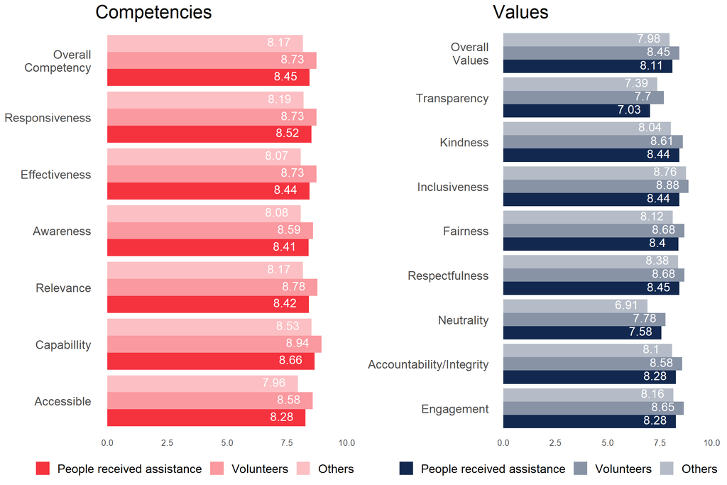

Download Summary Excel File